# Data Visualization and Data Reduction

Anil

# Significance

## The industry problem

Imagine an e-commerce company with **100 million transactions**. Each record may contain:

- Customer ID
- Product
- Price
- Date and time
- Location
- Payment method
- Customer reviews

Managers want to know:

- Which products sell the most?
- Are sales increasing or decreasing?
- Which customers may buy again?
- Are there unusual transactions?
- Can we build a machine-learning model efficiently?

**Opening question:** Would you open a file containing 100 million rows and inspect it manually?

**Key idea:** We need ways to understand large datasets and make analysis efficient.

# The Big Picture

## Two major challenges

**Challenge 1: “I cannot easily understand my data.”**

Use **data visualization** to reveal trends, patterns, relationships, groups, and unusual observations.

**Challenge 2: “My data is too large or complex to process efficiently.”**

Use **data reduction** to create a smaller representation while preserving the information needed for analysis.

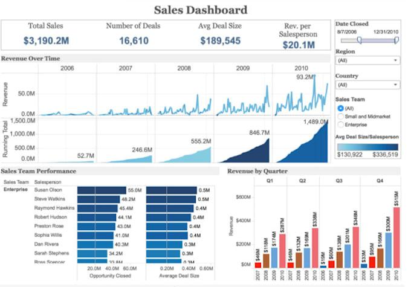

```r
knitr::include_graphics("dataimg.jpeg")
```

# Data Visualization

## From raw records to insight

Raw records are difficult to interpret when there are thousands or millions of rows.

A chart can help a person quickly identify:

- Trends over time
- Relationships between variables
- Differences between groups
- Outliers and unusual values
- Distributions and concentrations

**Definition:** Data visualization represents data graphically so that patterns and relationships are easier to understand.

# Example: Advertising and Sales

## Discovering a relationship

A company wants to know whether advertising expenditure is related to sales.

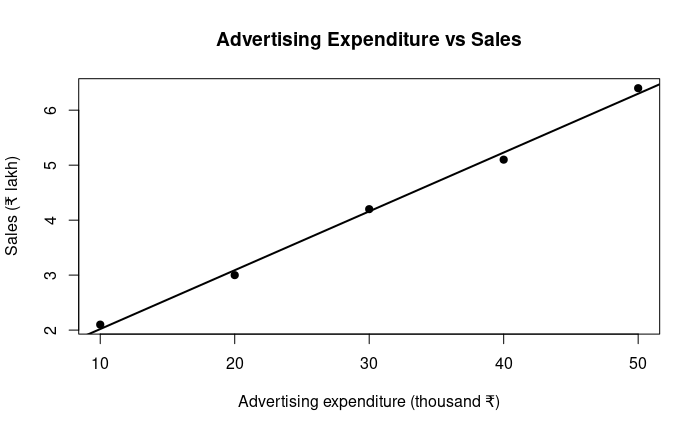

- Do sales tend to increase as advertising increases?
- Does a relationship prove that advertising alone caused the increase?

**Industry application:** Marketing analytics, campaign evaluation, and demand planning.

# Scatter Plots in Industry

| Variables | Possible use |
| --- | --- |
| Advertising expenditure and sales | Marketing analysis |
| Product price and demand | Pricing decisions |
| Experience and salary | Workforce analytics |
| Engine temperature and vibration | Predictive maintenance |
| Transaction amount and frequency | Fraud investigation |

A scatter plot helps explore a relationship between two numeric variables. The pattern may suggest positive, negative, or weak/no correlation.

**Caution:** Correlation does not by itself establish causation.

# Visualizing High-Dimensional Data

## What if there are many attributes?

A customer dataset might include:

- Age
- Income
- Spending
- Credit score
- Number of visits
- Purchases
- Complaints

A single 2-D scatter plot can show only two numeric dimensions at a time.

- Scatter plots and 3-D scatter plots
- Scatter-plot matrices
- Parallel coordinates
- Pixel-oriented visualization

**Industry applications:** Customer analytics, banking, healthcare, manufacturing, and sensor monitoring.

# Hierarchical Visualization

## Representing categories within categories

Example: an online news service.

- News
  - Sports
    - Cricket
    - Football
  - Technology
    - Artificial Intelligence
    - Cybersecurity
  - Business
    - Finance
    - Markets

Tree maps and other hierarchical displays can represent nested categories.

**Industry applications:** Product catalogues, file systems, organization structures, website navigation, and news classification.

# Complex Data and Graphs

## Visualizing relationships

Some data is best understood through connections rather than rows and columns.

Examples:

- People connected through social networks
- Products frequently bought together
- Accounts connected through money transfers
- Devices communicating in a network
- Diseases linked to symptoms or risk factors

**Industry applications:** Social-network analysis, recommendation systems, fraud investigation, cybersecurity, and knowledge graphs.

# Transition: Why Data Reduction?

## Understanding is not the only challenge

Suppose a bank stores millions of transactions, each with hundreds of attributes.

Even if charts help us explore the data, large and complex datasets may still require substantial storage and computation.

**Data reduction** creates a smaller representation of the data while aiming to preserve the information needed for analysis.

The goal is not simply to delete data. It is to reduce size while retaining useful analytical results.

# Three Main Data-Reduction Strategies

## A map of the topic

| Strategy | Main question | Examples from the unit |
| --- | --- | --- |
| Dimensionality reduction | Can we reduce the number of attributes? | Wavelet transforms, PCA, attribute subset selection |
| Numerosity reduction | Can we represent many records more compactly? | Regression, log-linear models, histograms, clustering, sampling, data-cube aggregation |
| Data compression | Can data be stored in a smaller representation? | Lossless and lossy compression |

The best technique depends on the data and the analysis task.

# PCA: Principal Component Analysis

## Many variables, fewer components

Imagine a dataset with 100 numeric attributes describing customers or products.

PCA transforms the original variables into a smaller set of new variables called **principal components**, ordered by how much variation they explain.

Conceptually:

**100 original attributes → PCA → a smaller set of components**

**Applications:**

- Exploring high-dimensional datasets
- Reducing inputs before some machine-learning tasks
- Visualizing complex data in two or three dimensions
- Identifying dominant patterns in measurements

**Important:** PCA combines information into new components; it does not simply select a few original columns.

# Attribute Subset Selection

## Keep useful attributes

Suppose we want to predict employee salary from a dataset containing:

- Experience
- Education
- Skills
- Job role
- Employee ID
- Favourite colour

Some attributes may be useful; others may contribute little to the prediction.

Attribute subset selection identifies and removes irrelevant or redundant attributes.

**Industry applications:** Feature selection for predictive modelling, customer churn analysis, and risk prediction.

**Discussion:** Would Employee ID normally help predict salary? Why or why not?

# Wavelet Transforms

## Keep important signal information

Wavelet transforms convert data into wavelet coefficients. For data reduction, a smaller representation can be obtained by retaining stronger coefficients and discarding or setting small coefficients to zero.

**Applications described or motivated by this technique include:**

- Image and signal processing
- Fingerprint-image compression
- Computer vision
- Time-series analysis
- Noise reduction

**Intuition:** Preserve the important structure while reducing less significant detail. Depending on the method, reconstruction may be approximate.

# Regression as a Compact Model

## Represent a relationship with an equation

Simple linear regression models a numeric response using a predictor:

$$y = wx + b$$

For example, a housing company may study the relationship between house area and selling price.

A fitted model can summarize a relationship and estimate prices for new areas.

**Industry applications:** Price estimation, demand forecasting, sales analysis, and trend modelling.

# Histograms

## Understand a distribution

A histogram groups numeric values into intervals called **bins** and displays how many observations fall into each interval.

**Questions:**

- Which transaction amounts occur most often?
- Is the distribution skewed?
- Are there unusually large transactions?

**Industry applications:** Retail pricing, banking, quality control, and transaction monitoring.

In this unit, histograms are also discussed as a way to summarize a distribution using fewer buckets than storing every individual value.

# Clustering

## Represent groups of similar records

Clustering groups objects so that records within a cluster are more similar to one another than to records in other clusters.

Example: customers grouped by annual spending and visit frequency.

**Applications:** Customer segmentation, document grouping, image analysis, and exploratory analysis.

For data reduction, cluster representatives can sometimes stand in for many records. The quality of this approach depends on whether the data form meaningful clusters.

# Sampling

## Use a subset to learn about a population

A company wants to estimate customer satisfaction across millions of customers. Surveying everyone may be too expensive.

A carefully selected sample can help estimate population characteristics.

Important methods include:

- Simple random sampling
- Sampling with replacement
- Cluster sampling
- Stratified sampling

**Industry applications:** Customer surveys, quality inspection, auditing, and exploratory analysis.

**Caution:** A sample must be selected appropriately. A biased sample may give misleading conclusions.

# Stratified Sampling: University Example

## Ensure different groups are represented

Suppose a university has students from CSE, ECE, EEE, and Mechanical Engineering.

If we sample students without considering department, smaller departments might be underrepresented.

In **stratified sampling**, divide the population into groups (strata), then sample from each group.

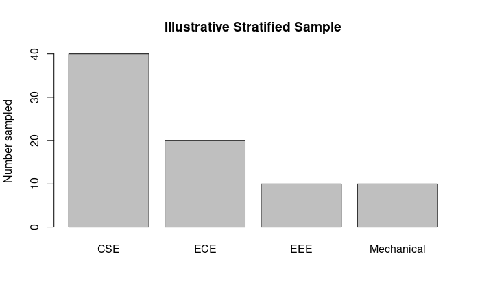

```r
departments <- c("CSE", "ECE", "EEE", "Mechanical")
population <- c(2000, 1000, 500, 500)
sample_n <- c(40, 20, 10, 10)
barplot(sample_n,
        names.arg = departments,
        col = "grey75",
        main = "Illustrative Stratified Sample",
        ylab = "Number sampled")
```

The sample counts here are illustrative, not a required sampling formula. In practice, choose the allocation according to the study goal.

# Data-Cube Aggregation

## Summarize detailed records

A retailer may store sales by branch, product, quarter, and year.

If management asks for annual sales, quarterly values can be aggregated:

**Quarterly sales → Sum by year → Annual sales**

A data cube organizes summarized measures across dimensions such as time, product, and branch.

**Industry applications:**

- Business intelligence dashboards
- Retail performance analysis
- Financial reporting
- Online Analytical Processing (OLAP)

Aggregation reduces the amount of detail needed for a particular question, but it may hide patterns that exist at finer levels.

A bank wants to investigate potentially fraudulent transactions.

| Technique | Possible role |
| --- | --- |
| Visualization | Explore unusual amounts and transaction patterns |
| Histograms | Understand the distribution of transaction values |
| Feature selection | Remove irrelevant or redundant fields |
| PCA | Reduce dimensions for suitable exploratory or modelling tasks |
| Sampling | Create a manageable subset for initial analysis |
| Clustering | Explore groups of similar transactions |
| Regression | Model numeric relationships where appropriate |
| Aggregation | Summarize transactions by customer, merchant, or time |

These techniques support investigation and modelling; **none of them alone guarantees fraud detection**. Real systems also need validation, suitable labels, domain knowledge, and safeguards.